# Suicidality and Coping in Male Veteran Sample with Mental Health Difficulties

```r
library(tidyverse)
library(rstanarm)
library(GGally)
library(corrplot)
```

Read Jahn data:

```r
setwd("/Users/peterphalen/Downloads/JAHNDATA/")
dat <- read_csv("suicide_combined_all.csv")
```

# 1.0 Preprocessing

I only care about COPE data so I restrict the sample to the 50 people with COPE data and then calculate all its subscales:

```r
# restrict to people with complete COPE data
dat <- dat[which(dat$cope_complete == 2),]
dat <- within(dat,
       {
       positive.reinterpretation.and.growth = cope_1 + cope_29 + cope_38 + cope_59
       mental.disengagement = cope_2 + cope_16 + cope_31 + cope_43
       focus.on.and.venting.of.emotions = cope_3 + cope_17 + cope_28 +cope_46
       instrumental.social.support = cope_4 + cope_14 + cope_30 + cope_45
       active.coping = cope_5 + cope_25 + cope_47 + cope_58
       denial = cope_6 + cope_27 + cope_40 + cope_57
       religious.coping = cope_7 + cope_18 + cope_48 + cope_60
       humor = cope_8 + cope_20 + cope_36 + cope_50
       behavioral.disengagement = cope_9 + cope_24 + cope_37 + cope_51
       restraint = cope_10 + cope_22 + cope_41 + cope_49
       emotional.social.support = cope_11 + cope_23 + cope_34 + cope_52
       substance.use = cope_12 + cope_26 + cope_35 + cope_53
       acceptance = cope_13 + cope_21 + cope_44 + cope_54
       suppressing.competing.activities = cope_15 + cope_33 + cope_42 + cope_55
       planning = cope_19 + cope_32 + cope_39 + cope_56
       })

# To avoid retyping the scale names a bunch of times, we save a vector containing the names of all the subscales
cope.subscales <- c("positive.reinterpretation.and.growth",
                    "mental.disengagement",
                    "focus.on.and.venting.of.emotions",
                    "instrumental.social.support",
                    "active.coping",
                    "denial",
                    "religious.coping",
                    "humor",
                    "behavioral.disengagement",
                    "restraint",
                    "emotional.social.support",
                    "substance.use",
                    "acceptance",
                    "suppressing.competing.activities",
                    "planning")
```

Create some basic demographic variables.

```r
dat$marital <- factor(dat$marital, levels=1:4, labels=c("married","widowed","divorced","single"))
dat$race <- factor(dat$Race, levels=1:7, labels=c("AmerInd","AsianPI","AsianPI","Black","AsianPI","White","Multiple"))
dat$gender <- factor(dat$male, 0:1, labels=c("female","male"))
```

# 1.1 Descriptive statistics

Check distribution of demographic variables.

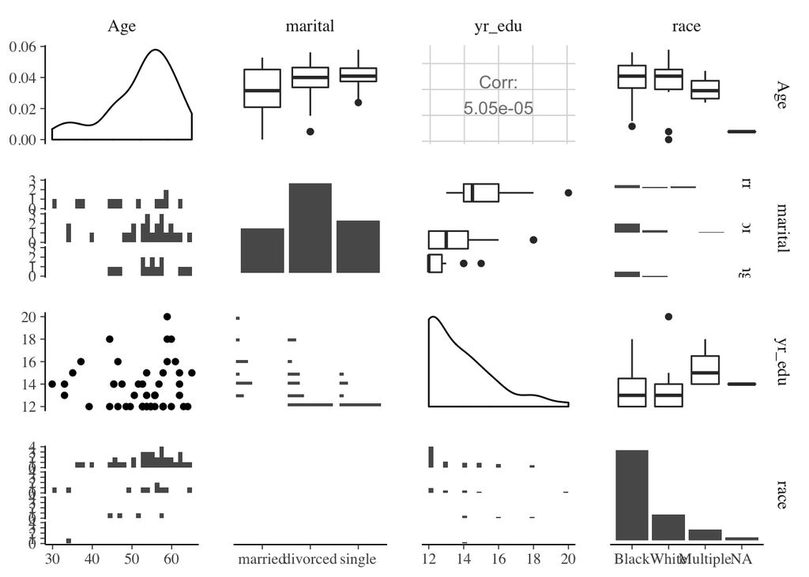

```r
demographic.vars <- c("Age",
                      "marital",
                      "yr_edu",
                      "race")

ggpairs(dat[demographic.vars])
```

Sample is all male so no point including this as a covariate:

```r
summary(dat$gender)
```

```
## female   male   NA's
##      0     49      1
```

Take a look at depression distribution, which we’ll also want to include in multivariate analyses.

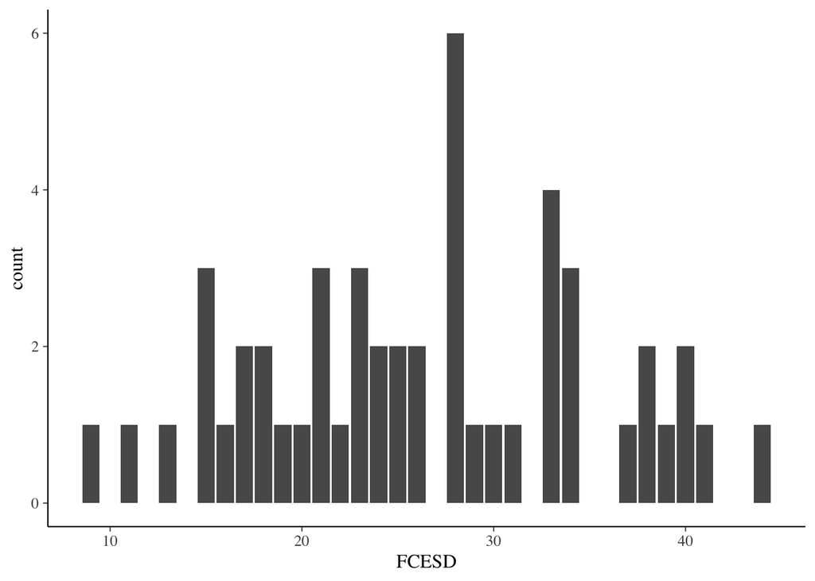

```r
ggplot(dat) +
  aes(x=FCESD) + # depression
  geom_bar()
```

# 2.0 Suicide ideation and coping

Here’s the distribution of suicidal ideation in the sample, as measured by the Beck Scale for Suicide Ideation (BSS). About half the sample has some level of suicidal ideation.

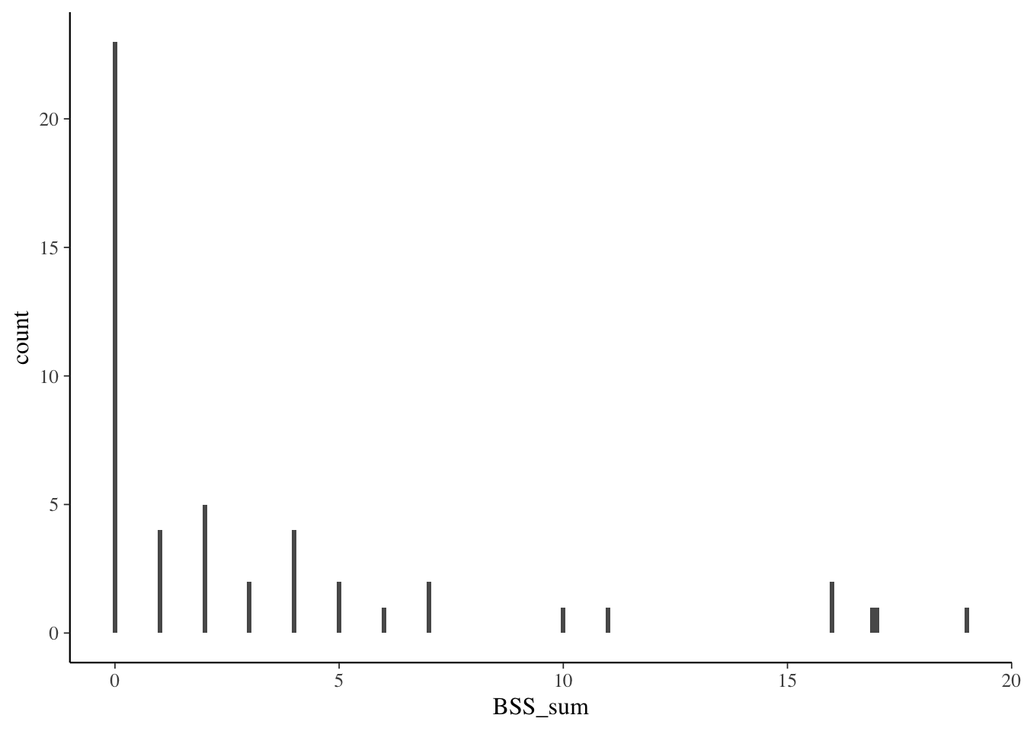

```r
ggplot(dat) +
  aes(x = BSS_sum) +
  geom_bar()
```

Log-transform of SSI probably makes the most sense–as confirmed by pairs plot farther down (relationships between BSS and subscales are log-linear).

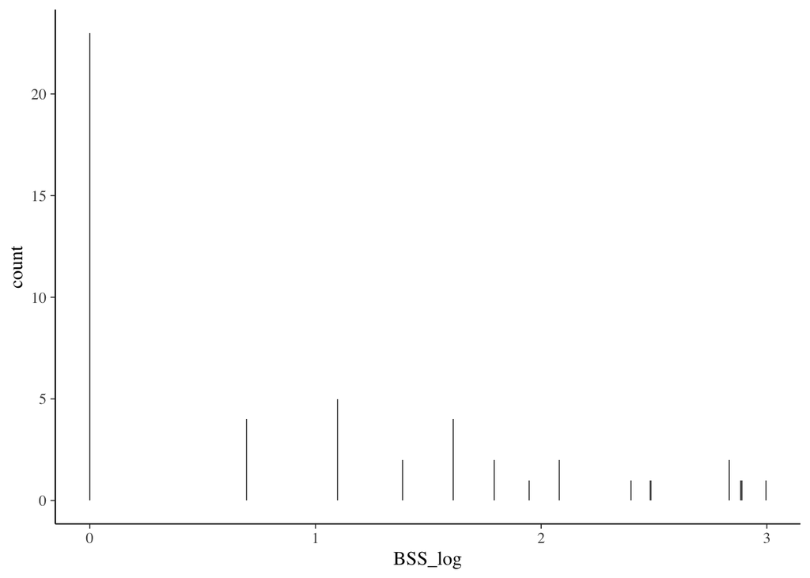

```r
dat$BSS_log <- log(dat$BSS_sum + 1)
ggplot(dat) +
  aes(x = BSS_log) +
  geom_bar()
```

## 2.1 Exploratory correlations

We first run correlations between all the COPE subscales and suicide ideation (`BSS_log`). Darker red indicates a more positive correlation. Darker blue indicates more negative.

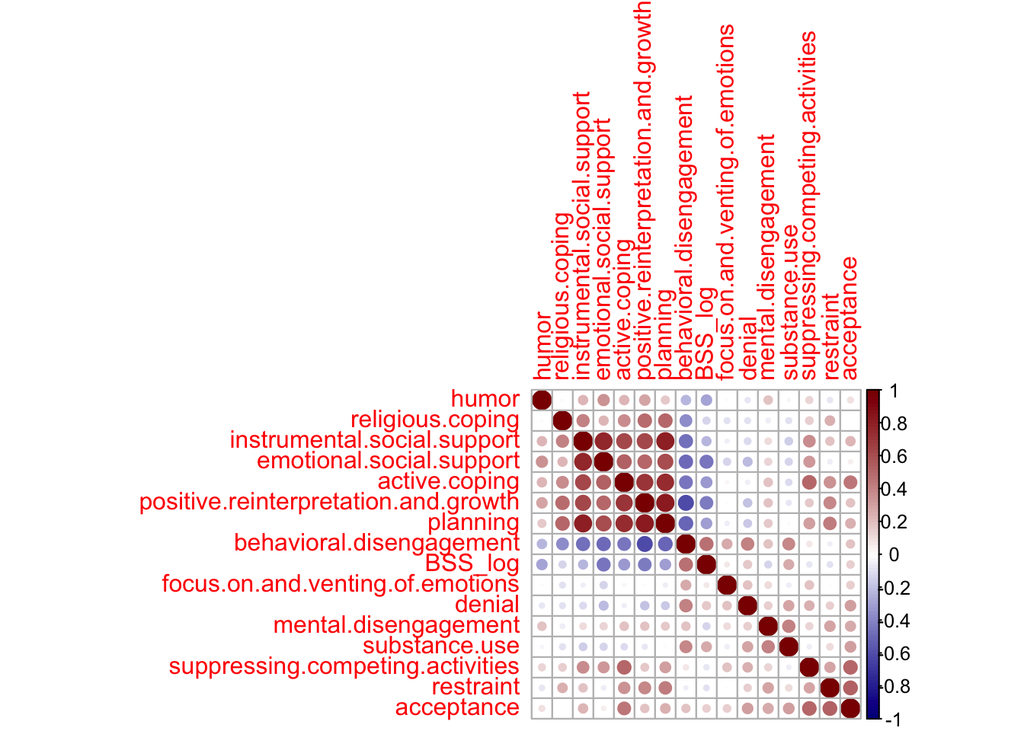

```r
M<-cor(dat[c(cope.subscales,"BSS_log")], use = "pairwise.complete.obs")
corrplot(M, method="circle", order="hclust",col=colorRampPalette(c("darkblue", "white", "darkred"))(100))
```

#### Filtering on statistical significance

Now we want to make a version that filters for significance. To do this, we need to define a function that calculates p-values.

```r
# mat : is a matrix of data
# ... : further arguments to pass to the native R cor.test function
cor.mtest <- function(mat, ...) {
    mat <- as.matrix(mat)
    n <- ncol(mat)
    p.mat<- matrix(NA, n, n)
    diag(p.mat) <- 0
    for (i in 1:(n - 1)) {
        for (j in (i + 1):n) {
            tmp <- cor.test(mat[, i], mat[, j], ...)
            p.mat[i, j] <- p.mat[j, i] <- tmp$p.value
        }
    }
  colnames(p.mat) <- rownames(p.mat) <- colnames(mat)
  p.mat
}
```

And we use it to make our plot. Nonsignificant correlations (p>.05) how have an X drawn over them.

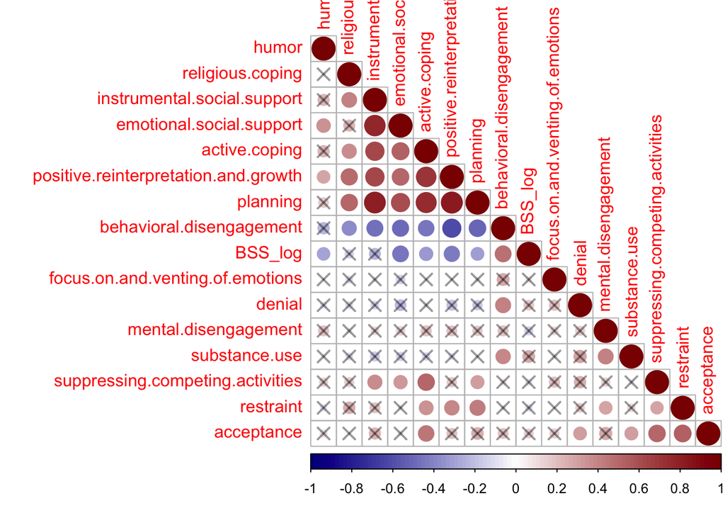

```r
# matrix of the p-value of the correlation
p.mat <- cor.mtest(dat[c(cope.subscales,"BSS_log")])
corrplot(M, type="lower", order="hclust",
         col=colorRampPalette(c("darkblue", "white", "darkred"))(100),
         p.mat = p.mat, sig.level = 0.05,
         insig="pch", pch=4, pch.cex=1.5,
         pch.col=rgb(0,0,0,.4))
```

#### Check the most relevant variables

Look at relationship between SI and the statistically significant variables in some more detail.

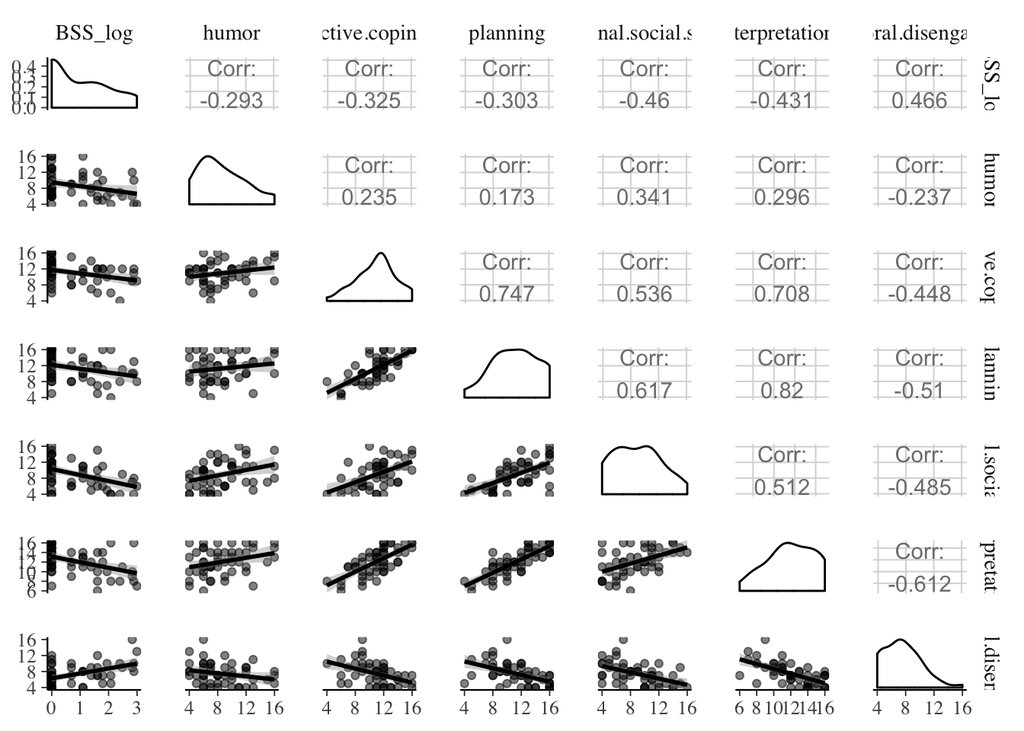

```r
ggpairs(subset(dat, select=c(BSS_log,
                             humor,
                             active.coping,
                             planning,
                             emotional.social.support,
                             positive.reinterpretation.and.growth,
                             behavioral.disengagement)),
        lower=list(continuous=wrap("smooth", col=rgb(0,0,0,alpha=.5))))
```

## 2.2 Multivariate analysis

Fit model, z-scoring continuous variables so that coefficients are easily comparable.

```r
fit <- stan_glm(BSS_log ~
                marital +
                race +
                # z-score the continuous predictors to put them on a common scale
                 scale(yr_edu) +
                 scale(Age) +
                 scale(FCESD) +
                 scale(humor) +
                 scale(active.coping) +
                 scale(planning) +
                 scale(emotional.social.support) +
                 scale(positive.reinterpretation.and.growth) +
                 scale(behavioral.disengagement),
               iter=4000,
               cores=4,
               data=dat)
```

The model accounts for about 50% of the variance in suicidal ideation, which is very good.

```r
r2 <- bayes_R2(fit)
median(r2)
```

```
## [1] 0.5312891
```

Plot parameter estimates with 95% credible intervals and 80% credible intervals shaded.

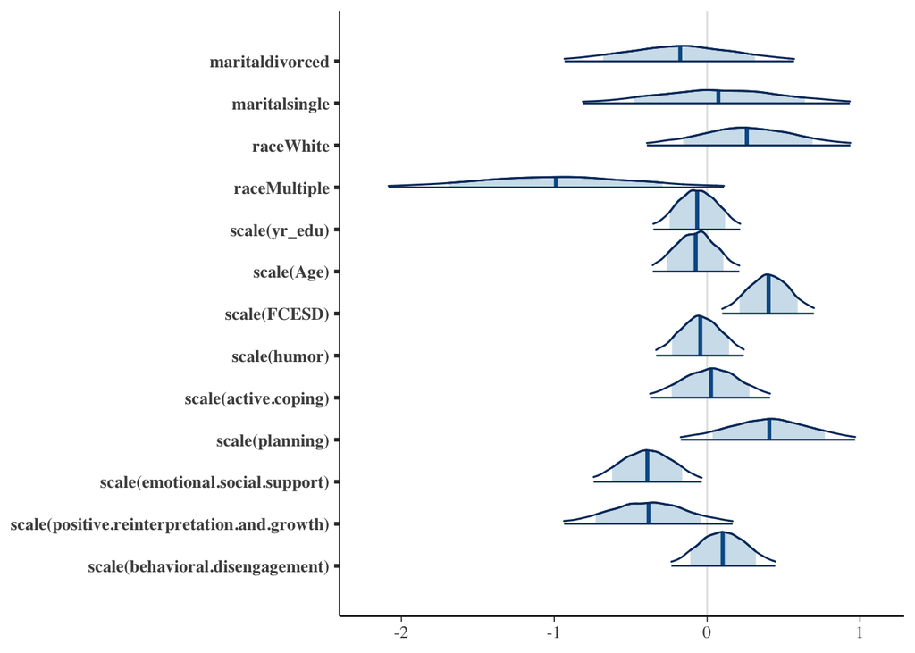

```r
plot(fit, "areas", pars="beta",
     prob_outer=.95, prob=.8)
```

For readability, replot without the demographic variables:

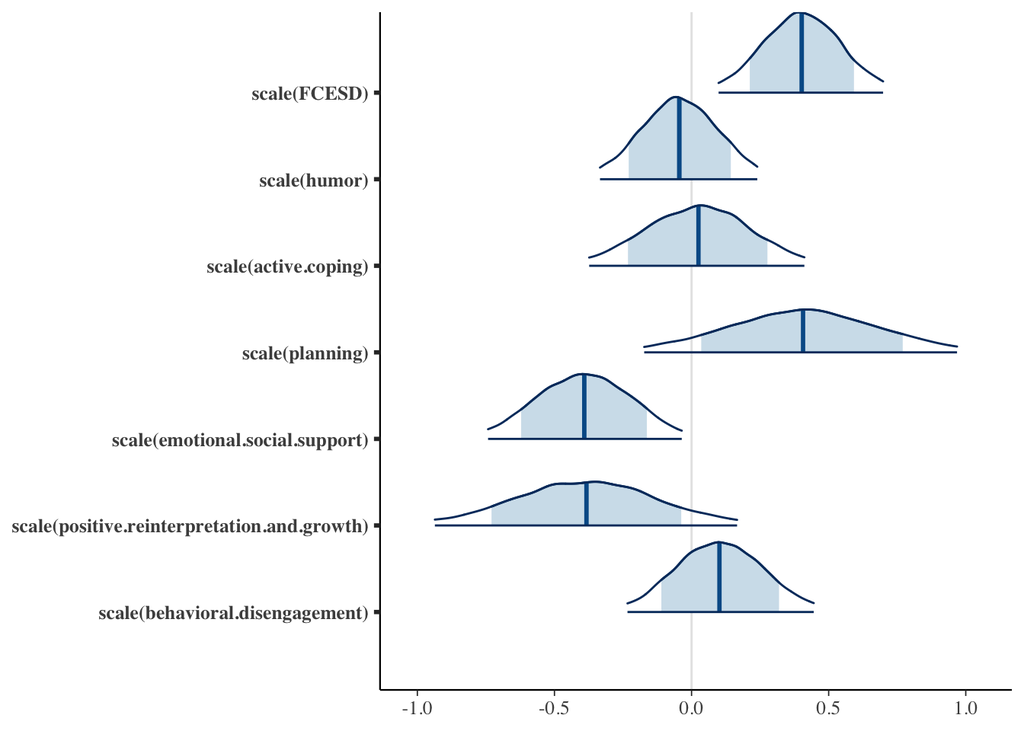

```r
plot(fit, "areas",
     pars=c("scale(FCESD)","scale(humor)","scale(active.coping)",
            "scale(planning)","scale(emotional.social.support)",
            "scale(positive.reinterpretation.and.growth)",
            "scale(behavioral.disengagement)"),
     prob_outer=.95, prob=.8)
```

## 2.3 Interpretation

Let’s think about what our model is saying. First of all, it is possible that certain coping strategies are more strongly associated with suicidality than depression, as some of the COPE subscale coefficients have large potential values. Let’s look at some of the COPE subscales in more detail. (You can check out the complete measure and scoring instructions [here](http://www.midss.org/sites/default/files/cope.pdf).)

#### Emotional Social Support

The `emotional social support` subscale is the only classically statistically significant COPE predictor in the model(–but PLEASE remember that [filtering on statistical significance leads to overconfident expectations of replicability](https://arxiv.org/pdf/1702.00556.pdf)). The subscale consists of the following four items:

- I discuss my feelings with someone
- I try to get emotional support from friends or relatives
- I get sympathy and understanding from someone
- I talk to someone about how I feel

These are the specific kinds of coping strategies that may be associated with decreased suicidality *even after controlling for depression.*

#### Positive Reinterpretation and Growth

- I try to grow as a person as a result of the experience.
- I try to see it in a different light, to make it seem more positive.
- I look for something good in what is happening
- I learn something from the experience.

Makes sense. These coping strategies are constructive and half of them are innately future-oriented.

#### Planning

Interestingly, `planning` may be associated with increased risk of suicidality. Let’s look at the items to figure out why this might be:

- I make a plan of action
- I try to come up with a strategy about what to do
- I think about how I might best handle the problem
- I think hard about what steps to take

Notice how none of these are action steps–at best they’re examples of “planning”, but they could also be described as “worrying”. It’s possible that, after controlling for other variables, these kinds of strategies serve as proxies for anxiety or distress.

# 3.0 Suicide attempts and coping

The next step is to look at the relationship between COPE subscales and suicide attempts (as opposed to ideation).

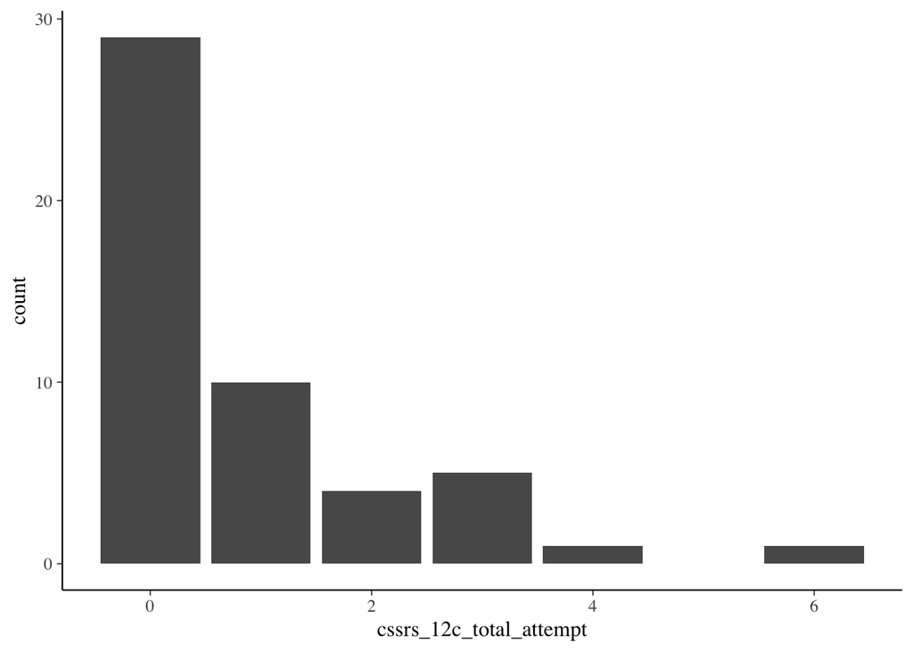

```r
ggplot(dat) +
  aes(x = cssrs_12c_total_attempt) +
  geom_bar()
```

Again, it probably makes sense to log-transform. After all, the difference between 0 and 1 suicide attempts is intuitively much greater than the difference between 1 and 2 suicide attempts.

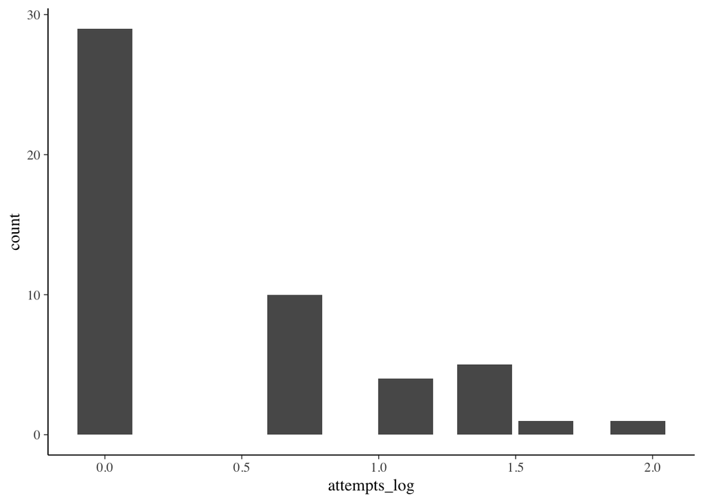

```r
dat$attempts_log <- log(dat$cssrs_12c_total_attempt + 1)
ggplot(dat) +
  aes(x = attempts_log) +
  geom_bar()
```

We first run correlations between all the COPE subscales and suicide attempts. In general, the relationships are weaker than those we measured with suicidal ideation. That’s not suprising… The COPE and suicide ideation measures are roughly contemporaneous, whereas distant suicide attempts could have very little relationship with current coping styles.

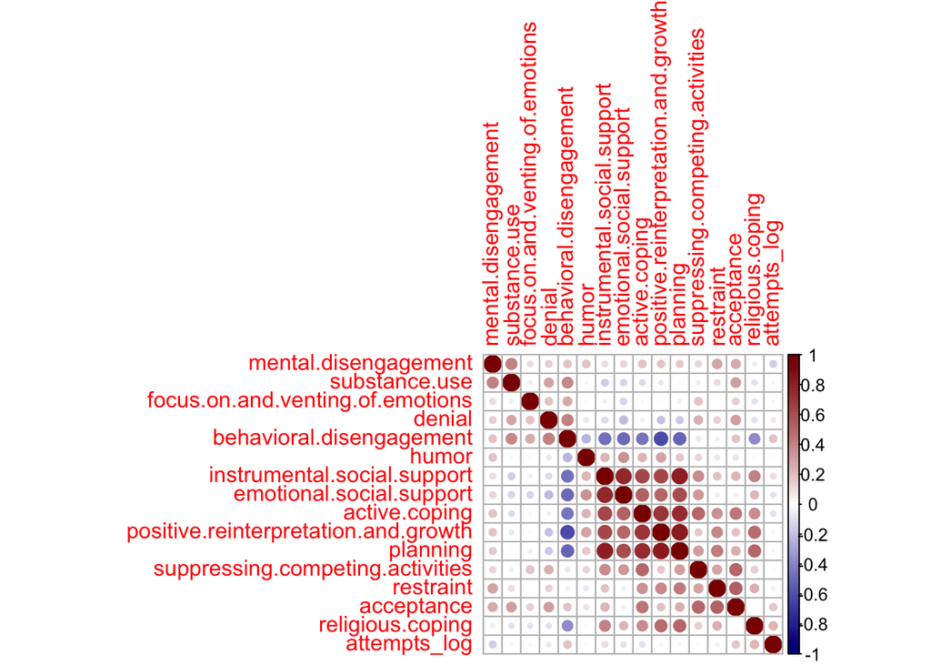

```r
M<-cor(dat[c(cope.subscales,"attempts_log")], use = "pairwise.complete.obs")
corrplot(M, method="circle", order="hclust",col=colorRampPalette(c("darkblue", "white", "darkred"))(100))
```

None of the correlations between coping styles and suicide attempts are classically statistically significant (and log-transforms don’t make much difference).

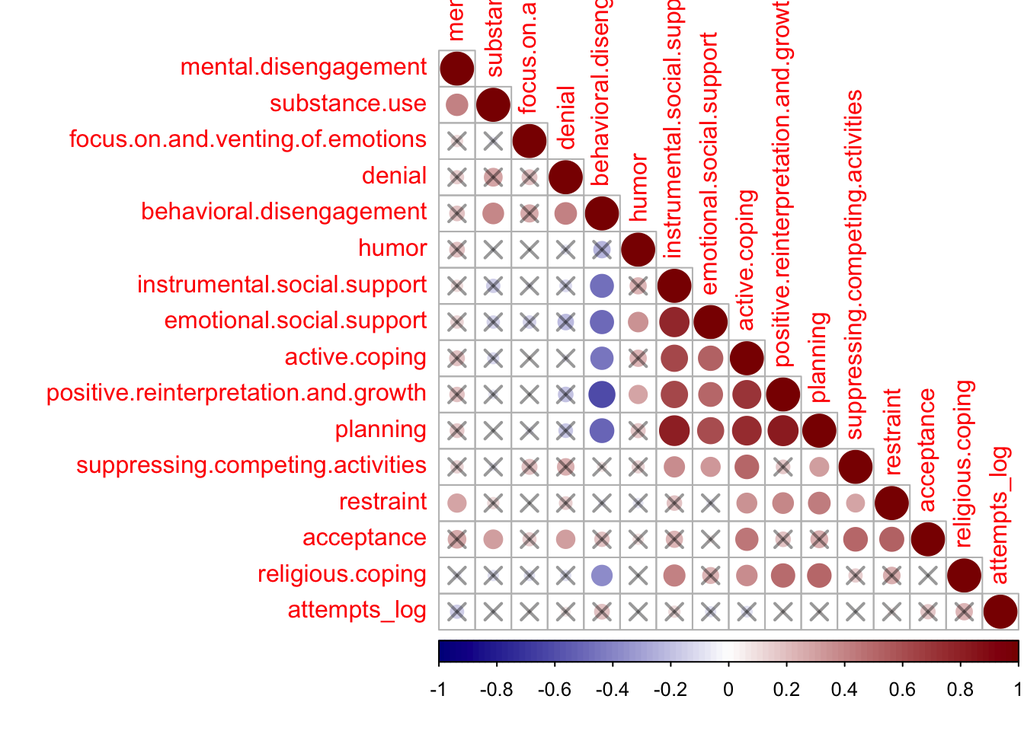

```r
p.mat <- cor.mtest(dat[c(cope.subscales,"attempts_log")])
corrplot(M, type="lower", order="hclust",
         col=colorRampPalette(c("darkblue", "white", "darkred"))(100),
         p.mat = p.mat, sig.level = 0.05,
         insig="pch", pch=4, pch.cex=1.5,
         pch.col=rgb(0,0,0,.4))
```

### Does binarizing change anything?

Maybe we’re reading too far into the number of suicide attempts… Suicide attempts are common in this sample, but in the general population, *any* history of suicide attempt would make you an outlier. So, we could try treating prior suicide attempts as a binary rather than a continuous variable.

```r
dat$prior_attempt <- dat$cssrs_12c_total_attempt > 0
table(dat$prior_attempt)
```

```
##
## FALSE  TRUE
##    29    21
```

We run 15 t-tests to see whether people with prior suicide attempts endorse the 15 COPE subscales to different degrees. However, only 1 of the 15 tests is significant (and only barely), so best not to overthink it.

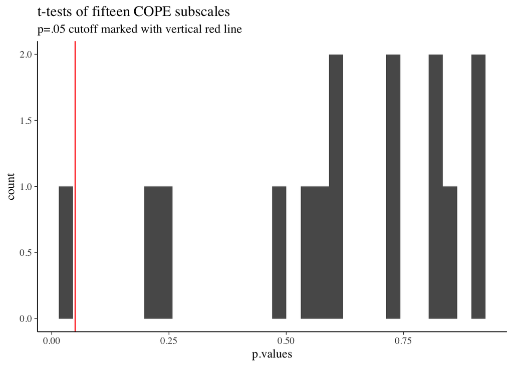

```r
tests <- lapply(dat[,as.character(cope.subscales[1:length(cope.subscales)])], function(x) t.test(x ~ dat$prior_attempt, var.equal = TRUE))
p.values <- data.frame(p.values = 1:length(tests))
for(test in 1:length(tests)){
  p.values[test,] <- tests[[test]]$p.value
}
ggplot(p.values) +
  aes(x = p.values) +
  geom_histogram() +
  geom_vline(xintercept=.05, col="red") +
  ggtitle("t-tests of fifteen COPE subscales", subtitle = "p=.05 cutoff marked with vertical red line")
```